# Eksperimenter

Metode 1 F25 #12

Søren Damsbo-Svendsen

7. maj 2025

## Temaer

- Eksperimenter
- Kausalitet

## Hovedpointer

- Eksperimenter er guldstandarden for *kausal inferens*
  - enkelt!
  - størst *interne validitet* (sikkerhed omkring den kausale effekt)
  - meget bedre end lineær regression på dette punkt
  - flere *typer* og mange udvidelser
  - ‘guldstandarden’ → samme logik, vi efterstræber, med andre kausale metoder
- Selvfølgelig også *ulemper*, *udfordringer* og *antagelser*
  - antagelserne er simple: *randomisering* + 2 andre
  - ulemper har fx at gøre med *ekstern/økologisk validitet*
  - eller mere praktiske problemer og begrænsninger

## Plan for forelæsningen

1. Recap: multipel regression – og kausalitet
2. Eksperimenter
   - eksperiment – trin for trin
   - treatmenteffekter og kausalitet
   - kausaldiagram
   - de tre antagelser
3. Live-eksperiment
4. Typer af eksperimenter
   - eksempler
5. Udfordringer og ulemper
6. Etiske overvejelser

## *Recap:* multipel regression – og kausalitet

- Man kan godt lave **kausal inferens** med regression
  - kontrollér for alle confounders, der påvirker X og Y
  - OLS eliminerer deres indflydelse ved at fjerne den varians i X og Y, de er skyld i
- **Udfordringen:**
  - der kan være confounders, vi ikke har målt
  - der kan altid være flere confounders, vi end ikke kender
  - kausaldiagrammet kan være komplekst
  - kausaldiagrammet (vores teori) kan være forkert
  - forkerte kontrolvariable kan introducere nye problemer med confounding
- Modelbaseret kausal inferens vha. kontrolvariable er uperfekt, afhængiger af teori og argumentation
  - **eksperimenter** kan løse alle disse udfordringer →

# Eksperimenter

## Eksperimenter

- ‘*Det eksperimentelle forskningsdesign*’
- Hjørnestenen i *designbaseret kausal inferens*
- På engelsk: ‘randomized controlled trial’ (RCT)
- **Kernebegreber:**
  - *treatment* (X)
  - *outcome* (Y)
  - *treatmentgruppe* (modtager treatment)
  - *kontrolgruppe* (modtager ikke treatment)
  - tilfældig tildeling af treatment (*randomisering*)
  - *kausal effekt* / *average treatment effect (ATE)*
    - forskellen i gruppernes gennemsnit af *outcome*-variablen (Y)

## Eksperimenter

- Udfordringen ved at lave kausal inferens med *observationelle data*  
  (fx lineær regression):
  - vi er aldrig sikre på, hvad der *former/påvirker X* (selection into treatment)
  - selv hvis vi ved det, så mangler vi ofte data
  - selv hvis vi har data, kan vi altid have overset noget  
    (kompleks, ofte ukendt ‘virkelighed’)
- Med **eksperimenter** tager vi sagen i egen hånd og *intervenerer* direkte!
  - *manipulerer*/påvirker X
  - designer et konkret **treatment** (noget vi kan give til nogen)
  - giver treatment til *nogen* – **tilfældigt!** – og holder helt styr på *hvem*
  - sammenligner *outcome* med *andre*, som *ikke* får treatment

## Eksperiment – trin for trin

1. Find *n* subjekter/deltagere til eksperimentet
2. Design et **treatment** (en pille, en tekst, en aktivitet, …), som du vil teste effekten af
3. Design/vælg et **outcome** (surveyspørgsmål, adfærd, begivenhed, …), som du er *interesseret* i og kan måle, og som forventes at *respondere* på treatment
4. Inddel subjekter/deltagere *tilfældigt* (!) i to grupper → *statistisk identiske grupper*  
   (trods små substantielle forskelle)
5. **Giv treatment** til alle i *treatmentgruppen*  
   (giv ingenting eller en *placebo* til kontrolgruppen)
6. **Mål outcomes** i begge grupper og **beregn** gruppernes *gennemsnit*
7. Analyse: **sammenlign gennemsnittene**
   - forskellen i gennemsnit (*diff-in-means*) = den *gennemsnitlige kausale effekt* (ATE)

## Treatmenteffekter og kausalitet

- *Kausalitet* beskrives ofte pba. ‘**potentielle outcomes**’
  - (mere om dette i Metode 2, inklusiv særlig notation)
  - essensen: værdien af den afhængige variabel har (mindst) *to potentielle outcomes*
  - et MED/efter modtagelse af *treatment*
  - et UDEN modtagelse af *treatment*
  - **vi observerer kun det ene outcome!**

## Treatmenteffekter og kausalitet

- Ethvert *treatment*, man kan forestille sig, har en teoretisk *effekt på alle individer*
  - *alle* har i teorien deres egen personlige effekt
  - denne effekt er defineret som *forskellen på de to potentielle outcomes* (MED og UDEN treatment) for det individ
  - den **kausale effekt af treatmentet** er defineret som *forskellen mellem disse to parallelle verdener/verdenstilstande*
  - problemet: vi kan observere den ene ‘verdenstilstand’, men *aldrig* den anden
  - “fundamental problem of causal inference” (Rubin)
- Derfor *ved* vi aldrig, hvad de **individuelle** treatmenteffekter er

## Treatmenteffekter og kausalitet

- Vi kan ikke identificere *individuelle* treatmenteffekter
- Men vi kan identificere den **gennemsnitlige treatmenteffekt** i en gruppe
- Vi kan gøre to grupper *statistisk ens*:
  - alle relevante variable har ens (sandsynligheds)fordelinger i begge
  - **regression:** hvis muligt, kunne vi i princippet *kontrollere* for alle faktorer, der gør dem forskellige
  - en langt sikrere metode: **tilfældig tildeling af treatment** (*randomisering*)
- Hvis vi *tilfældigt* placerer alle i enten *Gruppe A* eller *Gruppe B*, har vi ingen måder at gætte/forudsige gruppemedlemskab på efterfølgende
  - der er *ingen* (!) faktorer, som øger eller mindsker chancen for at komme i A eller B
  - ingen baggrundsvariable, som korrelerer med treatmentstatus
  - ingen *confounders*

## Treatmenteffekter og kausalitet

- Hvis gruppemedlemskab er tilfældigt, er grupperne *statistisk set* ens
- Betyder at *outcome* (Y) ikke varierer *systematisk* mellem de to grupper
- Vi forventer samme gennemsnit af Y i begge grupper UDEN treatment
- Men … vi giver den ene gruppe et treatment
  - det er den **eneste forskel (!)**
- Vi ved derfor – på gruppeniveau (dvs. *i gennemsnit*) – hvad outcome *ville have været* i treatmentgruppen, hvis de IKKE var blevet treated
  - → den *ville have været* det samme som gennemsnittet i kontrolgruppen
  - → kontrolgruppens gennemsnit er det *kontrafaktiske gennemsnit for treatmentgruppen*
- Forskellen i *outcome* mellem de to grupper = den *gennemsnitlige treatmenteffekt* (ATE)
  - generelt dette, vi mener med den **‘kausale effekt’**

### Kausaldiagram: direkte sammenhæng (kausal?)

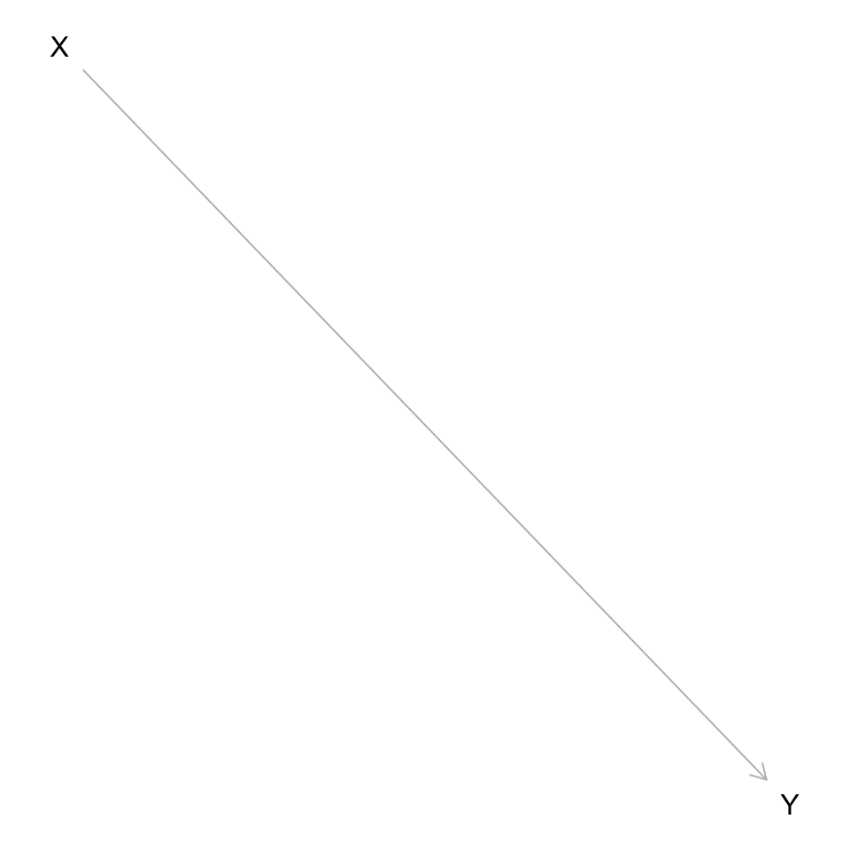

### Kausaldiagram: to confounders

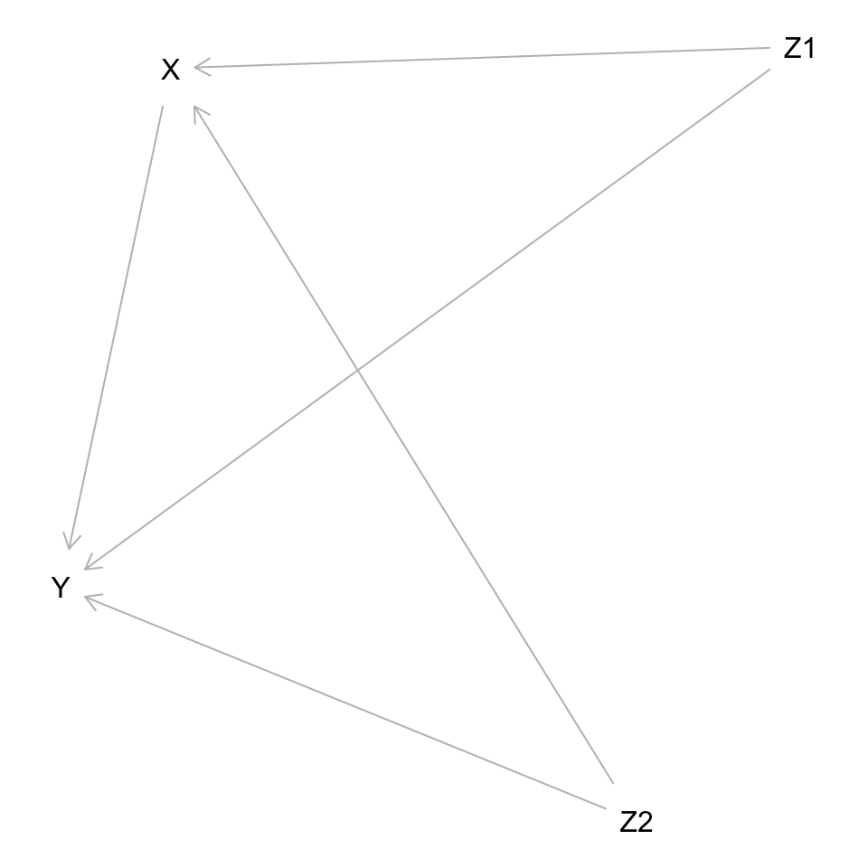

### Kausaldiagram: to confounders og tilfældigt tildelt treatment

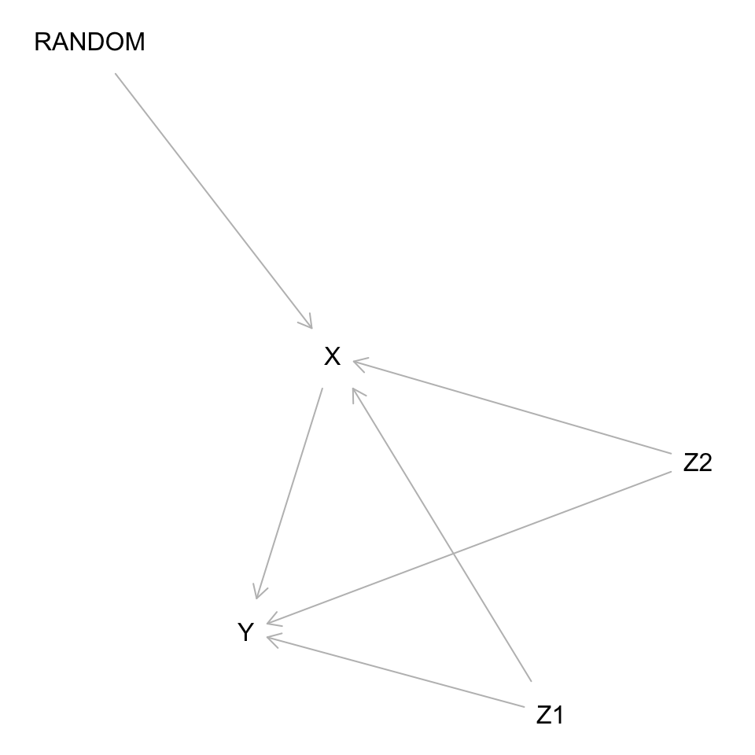

- Vi manipulerer X direkte
  - tilfældigt!
  - derfor INGEN pile *ind på* RANDOM
- Effekten af RANDOM påvirker kun Y via X (antagelse om *ekskluderbarhed*)
- Derfor er sammenhængen mellem RANDOM og Y fri for confounding og kan fortolkes som *effekten af X*

## Eksempel fra den virkelige verden (Valgundersøgelsen)

> Hvordan påvirker indkomst (1 lav - 15 høj) opbakning til højere beskatning af “høje indtægter” (1 lav - 5 høj)

**Kode**

```r
vu_select <- vu |>
  transmute(
    # holdning til beskatning af høje indtægter
    hojere_beskatning = scales::rescale(as.double(Q47_1), to = c(5, 1)),
    # indkomst
    indkomst = Q78,
    # ideologi
    venstre_hojre = Q64_0,
    # uddannelse
    uddannelse = udd,
    # alder
    alder = alder_på_valgdag,
    # køn
    mand = case_when(gender == 1 ~ 1,
                     gender == 2 ~ 0,
                     .default = NA))
```

> Der er mange *kendte confounders* af sammenhængen **indkomst → hojere_beskatning**

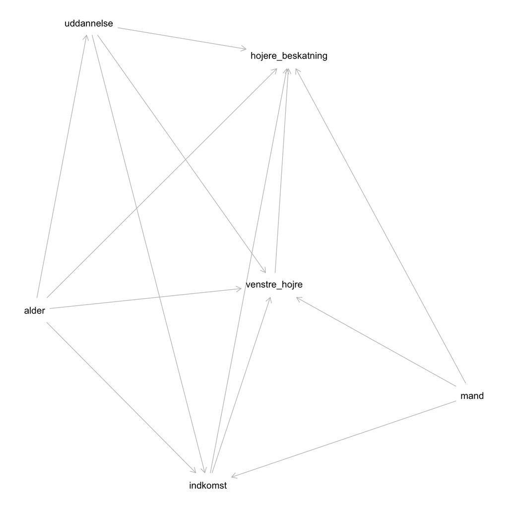

> Der kan også være mange *ukendte confounders*

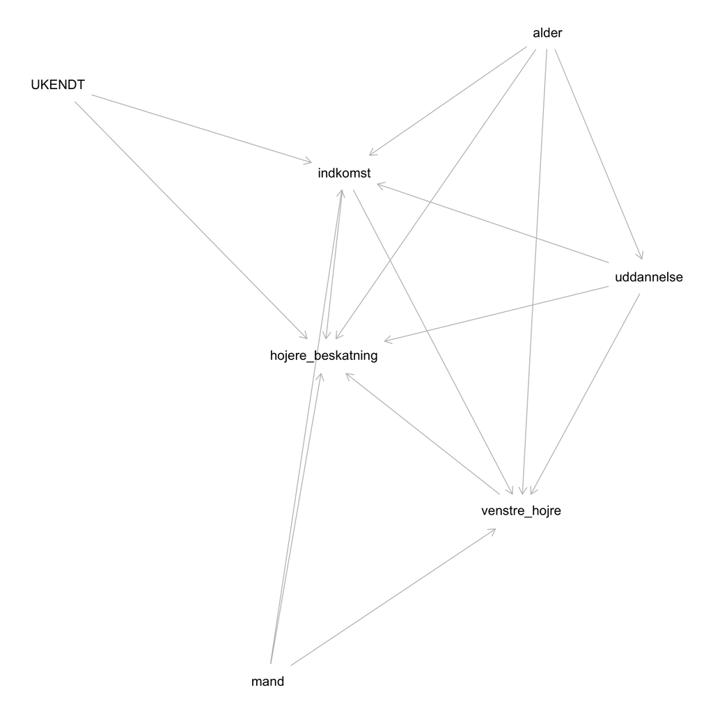

> Løsning: vi kan overkomme problemet, hvis vi direkte *manipulerer indkomst*!

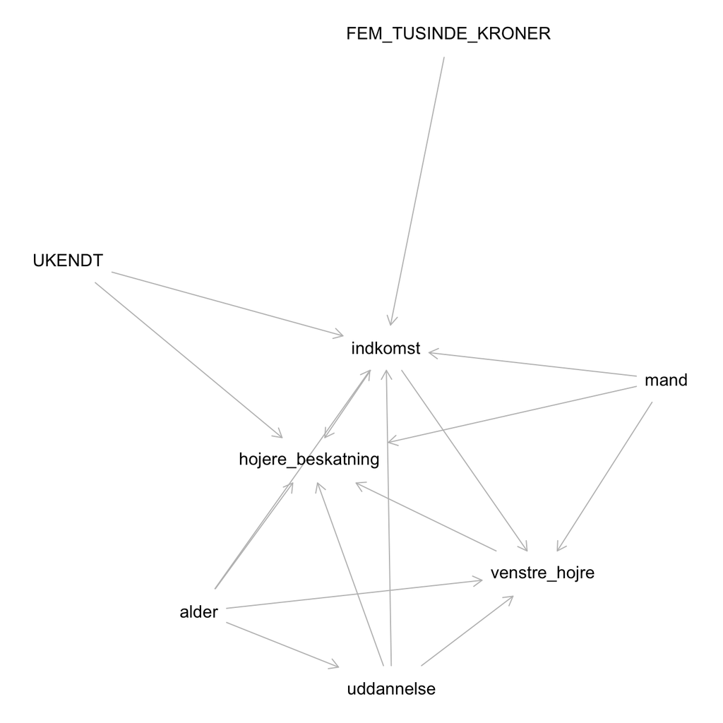

## De tre antagelser

1. Tilfældig inddeling af treatment og kontrolgruppe (*randomisering*)
   - sikrer statistisk ensartethed
   - ingen måde at gætte treatmentstatus
   - kontrolgruppens Y-gns. kan fungere som kontrafaktisk Y-gns. for treatmentgruppen
2. Kun én ting manipuleres (*ekskluderbarhed*)
   - hvis treatment påvirker/aktiverer flere faktorer, end den faktor (X), vi er interesserede i, ved vi ikke længere, hvordan en effekt skal fortolkes
   - eksempel: framingeksperiment, som framer *immigration* som nødvendigt for samfundsøkonomien
   - potentielt problem: en sådan frame er forbundet med bestemte partier
   - konsekvens: holdninger påvirkes både af selve *framen* og af partipolitiske holdninger og følelser

## De tre antagelser

3. Deltagernes “rolle” i eksperimentet påvirker ikke de andre deltagere  
   (*fravær af interferens*)
   - taler deltagerne sammen, ved de hvem hinanden er?
   - påvirker treatment direkte andre deltagere (fx i en husholdning)

# Live-eksperiment

## Live-eksperiment

Vi skal lave et eksperiment, der omhandler jeres sikkert stærke idrætspolitiske holdninger til **Padel(tennis)**.

Baggrund: Padel(tennis) er i dag organiseret under *Dansk Tennis Forbund*.

1. Åbn https://flipacoin.win på din computer eller telefon
2. Kast en mønt og husk om du får **heads (krone)** eller **tails (plat)**
3. Dit **spørgeskemalink** afhænger af møntkastet:
   1. **tails (plat) → https://bit.ly/4iOF5ey**
   2. **heads (krone) → https://bit.ly/432Uceu**
4. Følg linket og besvar spørgeskemaet (frivilligt)

## Live-eksperiment – tekstvignette som treatment

[output not shown]

Kilde: Parafraseret fra www.tennisavisen.dk/skal-padel-vaere-en-del-af-tennissporten

## Live-eksperiment – eksperimentelt setup

- **Treatment:** Framing af idræts(om)organisering som et spørgsmål om penge og lyssky magtudøvelse
- **Outcome:** Opbakning til selvstændighed for Padelforbundet
  - “Padel-sporten bør fortsat være organiseret som en del af Dansk Tennis Forbund.”
  - 1 (helt uenig) – 4 (helt enig)
- **Resultat** (den kausale effekt af magtframing):
  - ???

## Live-eksperiment – problemer?

1. **Treatment**
   - god operationalisering af “magtframing”?
   - stærkt/svagt, tvetydigt?
   - endimensionelt? eller varieres der reelt flere ting?
2. **Outcome**
   - spørgsmål og svarmuligheder?
   - forbindelse til treatment?
3. **Antagelser**
   1. Tilfældig inddeling af treatment og kontrolgruppe (*randomisering*)
   2. Kun én ting manipuleres (*ekskluderbarhed*)
   3. Deltagerne påvirker ikke de andre deltagere (*fravær af interferens*)
4. **Sample**

## Spørgsmål?

# Typer af eksperimenter

1. Laboratorieeksperiment
2. Felteksperiment
3. Surveyeksperiment
4. (Naturligt eksperiment)
5. (Kvasieksperiment)

### 1. Laboratorieeksperiment

- treatment administreres på samme lokation
- fuld kontrol over (potentielt ‘kunstige’) omgivelser
- potentielt ressourcekrævende

### 1. Laboratorieeksperiment – eksempel

- “Hunger Games: Fluctuations in Blood Glucose Levels Influence Support for Social Welfare”
- Aarøe & Petersen (2013), *Psychological Science*
- *n* = 104 studerende i Danmark
- Treatment: Sprite → højt blodsukker
  - placebo: Sprite Zero → lavt blodsukker
- Outcome: Holdning til velfærd (indeks)
- Resultat:
  - lavere blodsukker → større opbakning til velfærd/omfordeling
- Alt det i mellem: teori om, hvordan treatment virker (mekanismer), hvad det er udtryk for (fortolkning) osv.

### 2. Felteksperiment

- treatment administreres ude i ‘virkeligheden/felten’
- mindre kontrol over omgivelser
- meget realistisk
- ressourcekrævende

### 2. Felteksperiment – eksempel I

- “Local exposure to inequality raises support of people of low wealth for taxing the wealthy”
- Sands & de Kadt (2020), *Nature*

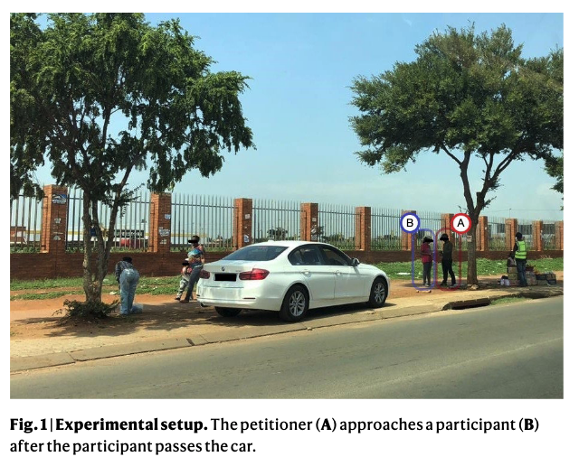

### 2. Felteksperiment – eksempel I

- *n* = 1,489 deltagere i Sydafrika
- Treatment: BMW 3 → reminder/prime om økonomisk ulighed
- Outcome: Underskriftindsamling for høj topskat
  - *placebo*-outcome: underskriftindsamling mod atomkraft
- Resultat:
  - større tilslutning til omfordeling
  - (endnu) større desto større lokal ulighed
- Alt det i mellem: teori om, hvordan treatment virker (mekanismer), hvad det er udtryk for (fortolkning) osv.

### 2. Felteksperiment – eksempel II

- “Can governments use Get Out The Vote letters to solve Europe’s turnout crisis? Evidence from a field experiment”
- Bhatti et al. (2017), *West European Politics*

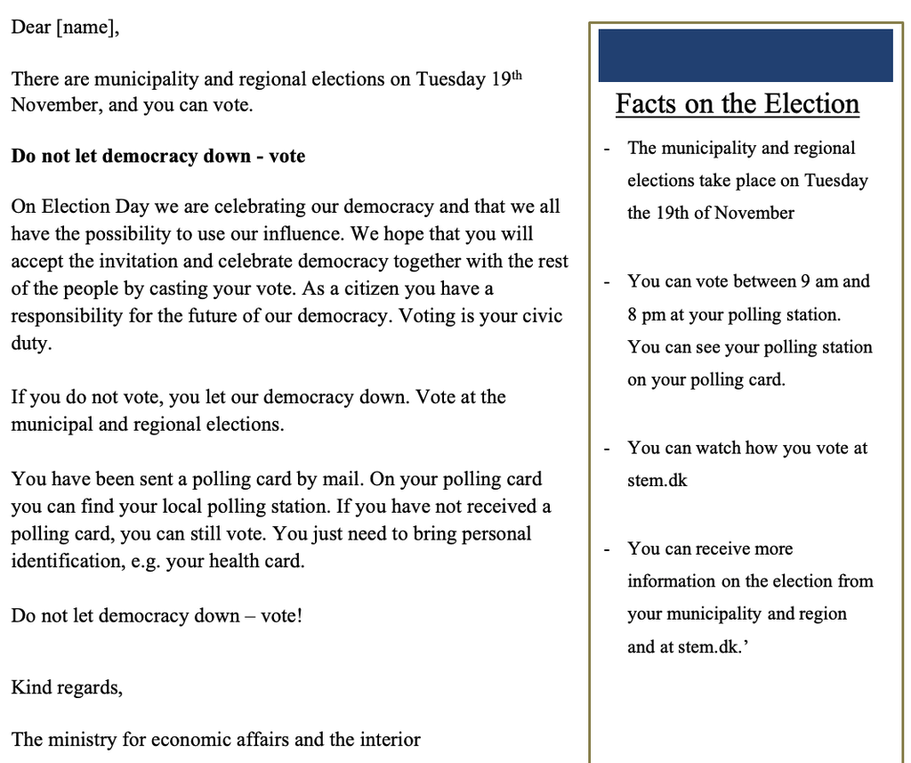

### 2. Felteksperiment – eksempel II

- *n* = 141,684 unge vælgere i Danmark
- Treatment: personligt *brev*
  - → reminder om at stemme + hvordan + hvorfor (8 versioner)
- Outcome: Stemmer de efterfølgende (ja/nej)?
- Resultat:
  - 0,5 %-point større chance for at stemme
  - Størst effekt af ‘duty/loss’ framing
  - Størst effekt for personer med lav tilbøjelighed til at stemme
- Alt det i mellem: teori om, hvordan treatment virker (mekanismer), hvad implikationerne er (fortolkning) osv.

## Typer af eksperimenter

1. Laboratorieeksperiment
2. Felteksperiment
3. **Surveyeksperiment →**
4. (Naturligt eksperiment)
5. (Kvasieksperiment)

### 3. Surveyeksperiment

- treatment administreres som del af et spørgeskema
- mindre kontrol over omgivelser
- begrænser både type og realisme af treatment
- ressourceeffektivt

# 3. Surveyeksperiment – eksempel *Aktivt forskningsprojekt om chikane af politikere*

## Overblik

- DIPAS (PI: Karina Kosiara-Pedersen, co-PI Christina Fiig, postdoc: mig)
- Surveyeksperiment
- 5.008 danske respondenter (tæt på nationalt repræsentativt)
- *Præregistreret* design, hypoteser og analyser
- Forskningsspørgsmål: *Hvordan påvirker chikane af politikere vores holdninger til demokrati, politik og chikane?*

## Overblik

[figure not shown]

**Kode**

```r
dat <- read_rds(here::here("Data", "dat_causal_mini.rds"))

count(dat, treated) |>
  kable()
```

Eksperimentgrupper

| treated | n |
| --- | --- |
| 0 | 2570 |
| 1 | 2438 |

## Treatment

1. Læser fem tilfældige sande historier om chikane af politikere
2. Evaluerer historierne på tre dimensioner (alvor, retfærdiggørelse, påvirkning)

Uddrag af 55 udvalgte chikanehistorier fra danske kommunalpolitikere (KV2021 kandidatsurvey)

| Chikanehistorie |
| --- |
| Jeg fik at vide af en vælger, at vedkommende kun ville stemme på mig, hvis de måtte bruge det kondom, som jeg havde uddelt i min valgkampagne, sammen med mig. |
| Jeg får ofte at vide af vælgere, at jeg ikke burde deltage i politik, men skulle blive hjemme med mine børn. |
| Et byrådsmedlem fra et andet parti skrev dårlige ting om mig til alle i mit parti og kørte en personlig hetz mod mig på sociale medier på grund af en kommentar, jeg havde skrevet derinde. |
| Engang forsøgte en gruppe på 6-7 yngre mænd at overfalde mig på vejen hjem fra et vælgermøde. Jeg har haft talrige lignende oplevelser. |
| Folk, jeg ikke kender, trængte på et tidspunkt ind på min private ejendom og klippede mit store valgbanner ned, mens jeg ikke var hjemme. |
| Jeg er blevet kørt på og nedgjort gennem hele valgkampen af en medkandidat fra mit eget parti på grund af mit køn og min alder. |
| Jeg har oplevet umotiverede, grove kommentarer på Facebook, såsom "lede svin, du er landsskadelig". |

## Outcomes

1. **Prevalence**: Hvor stor en andel af politikerne, tror du, oplever en form for chikane i løbet af en valgkamp? Giv dit bedste gæt (0% – 100%)
2. **Fear**: Jeg ville frygte selv at opleve chikane, hvis jeg en dag stillede op i politik (0 helt uenig – 100 helt enig)
3. **Attention**: Politikere, som klager over chikane og intimidering, er kun ude på at få opmærksomhed (0 helt uenig – 100 helt enig)
4. **Democracy**: Hvor tilfreds er du overordnet med det danske demokrati? (0 meget utilfreds – 100 meget tilfreds)
5. **Demonstration**: Hvor sandsynligt er det, at du på et tidspunkt vil deltage i en lovlig demonstration? (0 meget usandsynligt – 100 meget sandsynligt)

## Beskrivelse af variable

**Kode**

```r
dat |>
  select(treated, prevalence, fear, attention, democracy, demonstration) |>
  datasummary_skim()
```

Deskriptiv statistik

|  | Unique (#) | Missing (%) | Mean | SD | Min | Median | Max |  |
| --- | --- | --- | --- | --- | --- | --- | --- | --- |
| treated | 2 | 0 | 0.5 | 0.5 | 0.0 | 0.0 | 1.0 |  |
| prevalence | 102 | 6 | 61.7 | 24.0 | 0.0 | 65.0 | 100.0 |  |
| fear | 6 | 9 | 68.7 | 30.6 | 0.0 | 75.0 | 100.0 |  |
| attention | 6 | 5 | 27.8 | 27.3 | 0.0 | 25.0 | 100.0 |  |
| democracy | 6 | 2 | 64.1 | 28.2 | 0.0 | 75.0 | 100.0 |  |
| demonstration | 12 | 4 | 39.2 | 34.8 | 0.0 | 30.0 | 100.0 |  |

## Dataudsnit

**Kode**

```r
dat |>
  head(10) |>
  kable(digits = 1) |>
  kable_styling(font_size = 21)
```

Udsnit af datasættet: første 10 rækker

| treated | prevalence | fear | attention | demonstration | democracy | age | lrscale | gender | political_interest | conflict_avoid |
| --- | --- | --- | --- | --- | --- | --- | --- | --- | --- | --- |
| 0 | 70 | 75 | 25 | 30 | 75 | 29 | 5.0 | woman | 1 | 87.1 |
| 1 | 74 | 25 | 25 | 20 | 75 | 79 | 3.0 | man | 4 | 62.1 |
| 1 | 24 | 25 | 50 | 10 | 25 | 48 | 3.1 | man | 1 | 50.0 |
| 0 | 79 | 50 | 25 | 30 | 50 | 19 | 3.1 | woman | 1 | 75.0 |
| 1 | 74 | 75 | 0 | 100 | 100 | 75 | 4.0 | woman | 4 | 75.0 |
| 0 | 45 | 50 | 25 | 20 | 50 | 73 | 2.0 | woman | 1 | 75.7 |
| 1 | 70 | 75 | 50 | 20 | 75 | 78 | 2.0 | man | 4 | 87.9 |
| 0 | 25 | 50 | 50 | 0 | 75 | 56 | 1.0 | woman | 3 | 100.0 |
| 1 | 72 | 100 | 25 | 0 | 75 | 60 | 5.0 | man | 2 | 87.9 |
| 0 | 88 | 75 | 25 | 50 | 50 | 32 | 1.0 | woman | 2 | 75.0 |

## Gennemsnit

**Kode**

```r
dat |>
  group_by(treated) |>
  summarise(prevalence = mean(prevalence, na.rm = TRUE),
            fear = mean(fear, na.rm = TRUE),
            attention = mean(attention, na.rm = TRUE),
            demonstration = mean(demonstration, na.rm = TRUE),
            democracy = mean(democracy, na.rm = TRUE),
            age = mean(age, na.rm = TRUE),
            lrscale = mean(lrscale, na.rm = TRUE),
            gender = mean(gender == "man", na.rm = TRUE),
            political_interest = mean(political_interest, na.rm = TRUE),
            conflict_avoid = mean(conflict_avoid, na.rm = TRUE),
            .groups = "drop") |>
  kable(digits = 1) |>
  kable_styling(font_size = 21)
```

Gennemsnit af 5 outcomes og 5 baggrundsvariable i de to eksperimentgrupper

| treated | prevalence | fear | attention | demonstration | democracy | age | lrscale | gender | political_interest | conflict_avoid |
| --- | --- | --- | --- | --- | --- | --- | --- | --- | --- | --- |
| 0 | 59.3 | 66.7 | 29.9 | 36.6 | 64.6 | 51.6 | 3.1 | 0.5 | 2.7 | 75.1 |
| 1 | 64.1 | 70.8 | 25.6 | 41.9 | 63.6 | 51.8 | 3.0 | 0.5 | 2.7 | 74.2 |

1. Er treatment- og kontrolgruppen ens eller forskellige, jf. baggrundsvariablene?
2. Hvad er de kausale effekter af chikanehistorierne?<sup>1</sup>
3. Tør vi konkludere, at effekterne er ‘kausale’?
4. Er effekterne statistisk signifikante?
[^1]: **Prevalence**: Hvor stor en andel oplever chikane, **Fear**: Ville frygte selv at opleve chikane, **Attention**: De er kun ude på at få opmærksomhed, **Democracy**: Er tilfreds med det danske demokrati?, **Demonstration**: Vil deltage i en lovlig demonstration

## Analyse – OLS

```r
m1 <- lm(prevalence ~ treated, data = dat)
m2 <- lm(fear ~ treated, data = dat)
m3 <- lm(attention ~ treated, data = dat)
m4 <- lm(demonstration ~ treated, data = dat)
m5 <- lm(democracy ~ treated, data = dat)
```

**Kode**

```r
modelsummary(list("Prevalence" = m1, "Fear" = m2, "Attention" = m3, "Demonstration" = m4, "Democracy" = m5),
             # vælg output (eventuelt filnavn)
  output = "kableExtra",
  # titel
  title = "Effekten af at læse og lære om politikernes oplevelser med chikane på fem politiske outcomes",
  # regressionskoefficienter med signifikansstjerner?
  estimate = "{estimate}{stars}",
  # omdøb koefficient-navne
  coef_rename = c("(Intercept)" = "Konstant"),
  # vælg statistikker, formater label og tal
  gof_map = tibble::tribble(~raw,        ~clean,          ~fmt,
                            "nobs",      "N",             0,
                            "r.squared", "R<sup>2</sup>", 2),

  # tilpasninger fra kableExtra-pakken

  # antal decimaler
  fmt = 1) |>

  # skriftstørrelse (kableExtra)
  kable_styling(font_size = 21) |>

  # signifikansniveauer i fodnoten
  footnote(general = "OLS-regression. Standardfejl i parantes. *p < 0.05, **p < 0.01, ***p < 0.001. Data: Originalt surveyeksperiment (Damsbo-Svendsen & Kosiara-Pedersen 2025).")
```

Effekten af at læse og lære om politikernes oplevelser med chikane på fem politiske outcomes

|  | Prevalence | Fear | Attention | Demonstration | Democracy |
| --- | --- | --- | --- | --- | --- |
| Konstant | 59.3*** | 66.7*** | 29.9*** | 36.6*** | 64.6*** |
|  | (0.5) | (0.6) | (0.6) | (0.7) | (0.6) |
| treated | 4.8*** | 4.1*** | −4.3*** | 5.2*** | −1.0 |
|  | (0.7) | (0.9) | (0.8) | (1.0) | (0.8) |
| N | 4698 | 4545 | 4782 | 4817 | 4888 |
| R<sup>2</sup> | 0.01 | 0.00 | 0.01 | 0.01 | 0.00 |

Note:  
OLS-regression. Standardfejl i parantes. *p < 0.05, **p < 0.01, ***p < 0.001. Data: Originalt surveyeksperiment (Damsbo-Svendsen & Kosiara-Pedersen 2025).

## Analyse – t-test

```r
t_attention <- t.test(attention ~ treated,
                      data = dat)

t_attention
```

```
    Welch Two Sample t-test

data:  attention by treated
t = 5.422, df = 4779.8, p-value = 6.182e-08
alternative hypothesis: true difference in means between group 0 and group 1 is not equal to 0
95 percent confidence interval:
 2.723225 5.807817
sample estimates:
mean in group 0 mean in group 1
       29.86254        25.59701
```

**Kode**

```r
t_prevalence <- t.test(prevalence ~ treated, data = dat)
t_fear <- t.test(fear ~ treated, data = dat)
t_attention <- t.test(attention ~ treated, data = dat)
t_demonstration <- t.test(demonstration ~ treated, data = dat)
t_democracy <- t.test(democracy ~ treated, data = dat)

lst(t_prevalence, t_fear, t_attention, t_demonstration, t_democracy) |>
  map(broom::tidy) |>
  bind_rows(.id = "outcome") |>
  kable(digits = 1) |>
  kable_styling(font_size = 18)
```

| outcome | estimate | estimate1 | estimate2 | statistic | p.value | parameter | conf.low | conf.high | method | alternative |
| --- | --- | --- | --- | --- | --- | --- | --- | --- | --- | --- |
| t_prevalence | -4.8 | 59.3 | 64.1 | -6.9 | 0.0 | 4695.9 | -6.1 | -3.4 | Welch Two Sample t-test | two.sided |
| t_fear | -4.1 | 66.7 | 70.8 | -4.5 | 0.0 | 4531.4 | -5.9 | -2.3 | Welch Two Sample t-test | two.sided |
| t_attention | 4.3 | 29.9 | 25.6 | 5.4 | 0.0 | 4779.8 | 2.7 | 5.8 | Welch Two Sample t-test | two.sided |
| t_demonstration | -5.2 | 36.6 | 41.9 | -5.2 | 0.0 | 4796.5 | -7.2 | -3.3 | Welch Two Sample t-test | two.sided |
| t_democracy | 1.0 | 64.6 | 63.6 | 1.3 | 0.2 | 4869.7 | -0.5 | 2.6 | Welch Two Sample t-test | two.sided |

## Analyse – OLS med koefficientplot

**Kode**

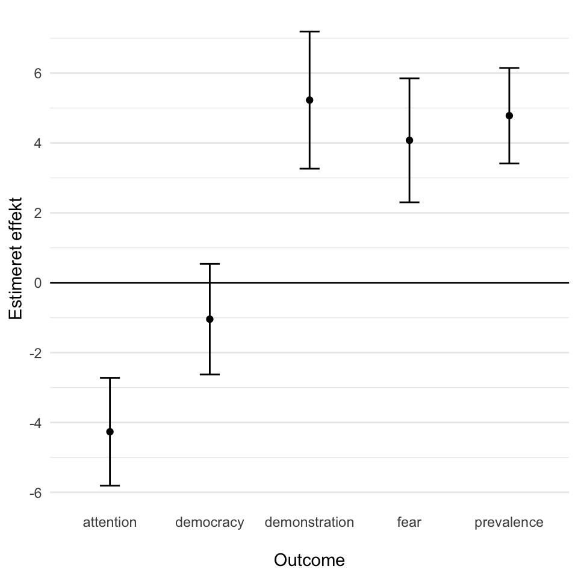

‘Coefplot’ af de estimerede effekter (diff-in-means) med 95%-konfidensintervaller

```r
m_prevalence <- lm(prevalence ~ treated, data = dat)
m_fear <- lm(fear ~ treated, data = dat)
m_attention <- lm(attention ~ treated, data = dat)
m_demonstration <- lm(demonstration ~ treated, data = dat)
m_democracy <- lm(democracy ~ treated, data = dat)

lst(m_prevalence, m_fear, m_attention, m_demonstration, m_democracy) |>
  map(broom::tidy, conf.int = TRUE) |>
  bind_rows(.id = "outcome") |>
  filter(term != "(Intercept)") |>
  mutate(outcome = str_remove(outcome, "m_")) |>
  ggplot() +
  aes(x = outcome, y = estimate, ymin = conf.low, ymax = conf.high) +
  geom_hline(yintercept = 0) +
  geom_point() +
  geom_errorbar(width = .2) +
  scale_y_continuous(breaks = seq(-6,6, 2)) +
  theme_minimal() +
  theme(panel.grid.major.x = element_blank()) +
  labs(x = "\nOutcome", y = "Estimeret effekt")
```

## Analyse – OLS med “kontrolvariable”

**Kode**

```r
m1 <- lm(attention ~ treated, data = dat)
m2 <- lm(attention ~ treated + age, data = dat)
m3 <- lm(attention ~ treated + lrscale, data = dat)
m4 <- lm(attention ~ treated + gender, data = dat)
m5 <- lm(attention ~ treated + political_interest, data = dat)
m6 <- lm(attention ~ treated + conflict_avoid, data = dat)
m7 <- lm(attention ~ treated + age + lrscale + gender + political_interest + conflict_avoid, data = dat)

modelsummary(list(m1, m2, m3, m4, m5, m6, m7),
             # vælg output (eventuelt filnavn)
  output = "kableExtra",
  # titel
  title = "Effekten af at læse og lære om politikernes oplevelser med chikane på attention",
  # regressionskoefficienter med signifikansstjerner?
  estimate = "{estimate}{stars}",
  # omdøb koefficient-navne
  coef_rename = c("(Intercept)" = "Konstant"),
  # vælg statistikker, formater label og tal
  gof_map = tibble::tribble(~raw,        ~clean,          ~fmt,
                            "nobs",      "N",             0,
                            "r.squared", "R<sup>2</sup>", 2),

  # tilpasninger fra kableExtra-pakken

  # antal decimaler
  fmt = 1) |>

  # skriftstørrelse (kableExtra)
  kable_styling(font_size = 19) |>

  # signifikansniveauer i fodnoten
  footnote(general_title = "", general = "Note: OLS-regression med attention som afhængig variabel. Standardfejl i parantes. *p < 0.05, **p < 0.01, ***p < 0.001. Data: Originalt surveyeksperiment (Damsbo-Svendsen & Kosiara-Pedersen 2025).")
```

## Analyse – OLS med “kontrolvariable”

Effekten af at læse og lære om politikernes oplevelser med chikane på attention

|  | Model 1 | Model 2 | Model 3 | Model 4 | Model 5 | Model 6 | Model 7 |
| --- | --- | --- | --- | --- | --- | --- | --- |
| Konstant | 29.9*** | 30.9*** | 44.0*** | 34.8*** | 40.0*** | 39.2*** | 67.5*** |
|  | (0.6) | (1.2) | (1.2) | (0.7) | (1.3) | (1.4) | (2.3) |
| treated | −4.3*** | −4.3*** | −4.5*** | −4.3*** | −4.2*** | −4.4*** | −4.4*** |
|  | (0.8) | (0.8) | (0.8) | (0.8) | (0.8) | (0.8) | (0.8) |
| age |  | 0.0 |  |  |  |  | 0.0 |
|  |  | (0.0) |  |  |  |  | (0.0) |
| lrscale |  |  | −4.6*** |  |  |  | −3.9*** |
|  |  |  | (0.3) |  |  |  | (0.3) |
| genderwoman |  |  |  | −9.3*** |  |  | −9.5*** |
|  |  |  |  | (0.8) |  |  | (0.8) |
| political_interest |  |  |  |  | −3.7*** |  | −5.4*** |
|  |  |  |  |  | (0.4) |  | (0.4) |
| conflict_avoid |  |  |  |  |  | −0.1*** | −0.1*** |
|  |  |  |  |  |  | (0.0) | (0.0) |
| N | 4782 | 4782 | 4782 | 4782 | 4782 | 4782 | 4782 |
| R<sup>2</sup> | 0.01 | 0.01 | 0.04 | 0.03 | 0.02 | 0.02 | 0.10 |

Note: OLS-regression med attention som afhængig variabel. Standardfejl i parantes. *p < 0.05, **p < 0.01, ***p < 0.001. Data: Originalt surveyeksperiment (Damsbo-Svendsen & Kosiara-Pedersen 2025).

### Kausaldiagram: flere uafhængige prediktorer

**Kode**

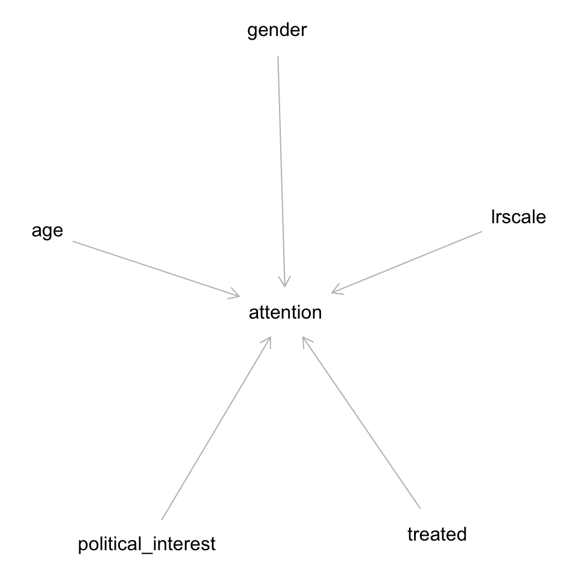

```r
library(dagitty)

dagitty("dag{
treated -> attention
age -> attention
lrscale -> attention
gender -> attention
political_interest -> attention
}") |> plot()
```

- Der er ingen *confounders* i eksperimenter
  - tredjevariable påvirker ikke X (treatment)
  - afkoblet af *randomiseringen*
- Derfor *behøver* vi ikke justere/kontrollere for dem
  - *unbiased* estimat af de kausale effekter uanset
- Tredjevariable kan dog spille en rolle ift. varians og statistisk signifikans
- Derudover kan de anvendes til at analysere *heterogene effekter* inden for forskellige grupper

# Udfordringer og ulemper ved eksperimenter

## Udfordringer og ulemper ved eksperimenter

- Den store **fordel:** få antagelser for valid kausal inferens (høj *intern validitet*)
- Potentielle **ulemper:**
  - eksperimentet/treatment ligner ikke “virkeligheden” (lav *økologisk validitet*)
    - typisk bedst med *felt*, værst med *laboratorie*/*survey*
  - effekten af eksperimentet/treatment kan ikke generaliseres, er meget kontekstafhængig (lav *ekstern validitet*)
    - typisk bedst med *survey*, sværere med *laboratorie*/*felt*
  - mange vigtige spørgsmål/emner kan slet ikke undersøges eksperimentelt
    - etiske begrænsninger
    - praktiske begrænsninger
    - videnskabelige begrænsninger
- Kræver grundig, ofte langvarig forberedelse og kan være ressourcekrævende

## Ikke-efterlevelse

- Sommetider afgør vi – vha. en randomiseringsprocedure – at et subjekt tilhører *treatmentgruppen*
- Men vi ved ikke, om de faktisk tager imod treatment – eller vi kan ikke håndhæve det
- Det er oftest et *tilbud*/en *opfordring*
  - (cue til etiske overvejelser…)
- At følge vores instruks og tage imod treatment kaldes **efterlevelse**
  - → *ikke-efterlevelse* er det modsatte
  - *compliers* vs. *non-compliers*

## Ikke-efterlevelse

- Hvis en vis andel af treatmentgruppen, ikke tager optager treatment:
  - kan vi ikke længere beregne den reelle gennemsnitseffekt af treatment (ATE)
  - forskellen på treatment og kontrolgruppen har dog stadig en (anden) kausal fortolkning:
  - *intention to treat* (ITT)-effekten
  - = den kausale effekt af at *tilbyde* treatment
- Vi kan også udlede den kausale effekt for *efterleverne* (CACE)
  - kræver at vi ved nøjagtigt, hvem der har optaget treatment

## Diverse udfordringer<sup>1</sup>

1. Deltagerne er uopmærksomme (optager ikke treatment)
2. Treatment er for svagt
3. Alle deltagere er allerede treated af ‘virkeligheden’
4. For lav statistisk *power* → for lille stikprøve til at ‘finde’ en statistisk signifikant effekt
5. *Upræcis måling* af outcome-variablen
6. Gulv- og loftseffekter → alle er tæt på toppen/bunden af svarskalaen
7. Modsatrettede treatmenteffekter udligner hinanden
[^2]: Kilde: Kane (2024), se også MIS

## Naturlige – og kvasieksperimenter

Ikke ‘rigtige’ eksperimenter i den forstand, at vi ikke har selv har designet treatment og kontrolleret tildelingen

- **Naturlige eksperimenter:**
  - ‘naturen’ laver et eksperiment med noget, der minder om tilfældig tildeling af et treatment
  - vi observerer tildelingen af treatment efterfølgende og måler et outcome
  - eksempel: naturkatastrofer
    - min egen forskning: lokal stormflod og stemme på klimavenlige partier
    - resultat: kraftig stormflod i DK flytter stemmer mod klimavenlige partier og lokale kandidater
    - problem: det er ikke (ubetinget) helt tilfældigt, hvem der rammes
    - derfor skal der alligevel statistisk kontrol til, så det bliver ‘mere tilfældigt’
    - kombi af designbaseret (eksperiment) og modelbaseret (regression)

## Naturlige – og kvasieksperimenter

- **Kvasieksperimenter:**
  - mere en *tankegang* end en konkret metode eller et design:
  - vi *observerer* frem for at manipulere et *treatment*,
  - men vi *efterligner eksperimentet* så meget som muligt
  - ved hjælp af konkrete **forskningsdesigns** (Metode 2)
    - fx zoomer vi ind på dele af data, hvor der faktisk er noget, der minder om tilfældig variation (RDD)
    - eller kombinerer på snedig vis med vores viden om andre variable (IV)
    - eller udnytter viden om udvikling over tid (DiD)

## Etiske overvejelser

- Man skal *altid* gøre sig grundige etiske overvejelser, inden man i videnskabens navn intervenerer i folks liv
  - sommetider skal det godkendes formelt
  - “do good”, “tread lightly”, “confess”, “compensate” (Desposato 2016)
- MIS-tjekliste (s. 300-302):
  1. Skade
  2. Vildledning
  3. Informeret samtykke
  4. Effekten af eksperimentet
  5. Videnskabelig værdi
  6. Værdien for deltagerne
  7. Antallet af deltagere
  8. Debriefing

## Opsummering

- **Eksperimenter** er guldstandarden for kausal inferens
  - fordi vi her har bedst kontrol over hele processen og og antagelserne er enkle
  - → som regel tårnøj intern validitet
  - *randomisering* af treatment er essentielt → ingen confounders
  - værdifuld reference for *kausal inferens* med andre metoder
- Grundlæggende design og analyse er enkel
  - sammenlign to ens (tilfældigt indelte!) grupper med kun én forskel: **treatment**
  - forskellen i gns. er alt, vi behøver → gns. treatmenteffekt (ATE)
- Der er også ulemper og udfordringer

## Næste uge

- Kvantitativ indholdsanalyse og tekstanalyse
- ‘Big data’ og ‘text-as-data’